# Coder Upgrade 2023: Cell Cell interaction analysis

Matt Cannon

04/25/2023

Load libraries

```r
library(rrrSingleCellUtils)
library(tidyverse)
library(Seurat)
library(nichenetr)

#.libPaths("/gpfs0/export/apps/opt/scrgot/23/lib/R")
```

# Section 1: Overview

## What is the goal of cell-cell interaction analysis?

## What are common tools used to do this?

CellphoneDB Cellchat

## Nichenetr

Nichenetr relies on a pre-defined model of ligand - target interactions It applies this model to your data to identify possible interactions

## Get their pre-defined model data

From: “https://zenodo.org/record/3260758/files/ligand_target_matrix.rds” “https://zenodo.org/record/3260758/files/lr_network.rds” “https://zenodo.org/record/3260758/files/weighted_networks.rds”

```r
ligand_target_matrix <-
    readRDS("/home/gdworkshop/lab/session_data/06/ligand_target_matrix.rds")

lr_network <-
    readRDS("/home/gdworkshop/lab/session_data/06/lr_network.rds")

weighted_networks <-
    readRDS("/home/gdworkshop/lab/session_data/06/weighted_networks.rds")

weighted_networks_lr <-
    weighted_networks$lr_sig %>%
    inner_join(lr_network %>% distinct(from, to),
               by = c("from", "to"))
```

## Get data to work with

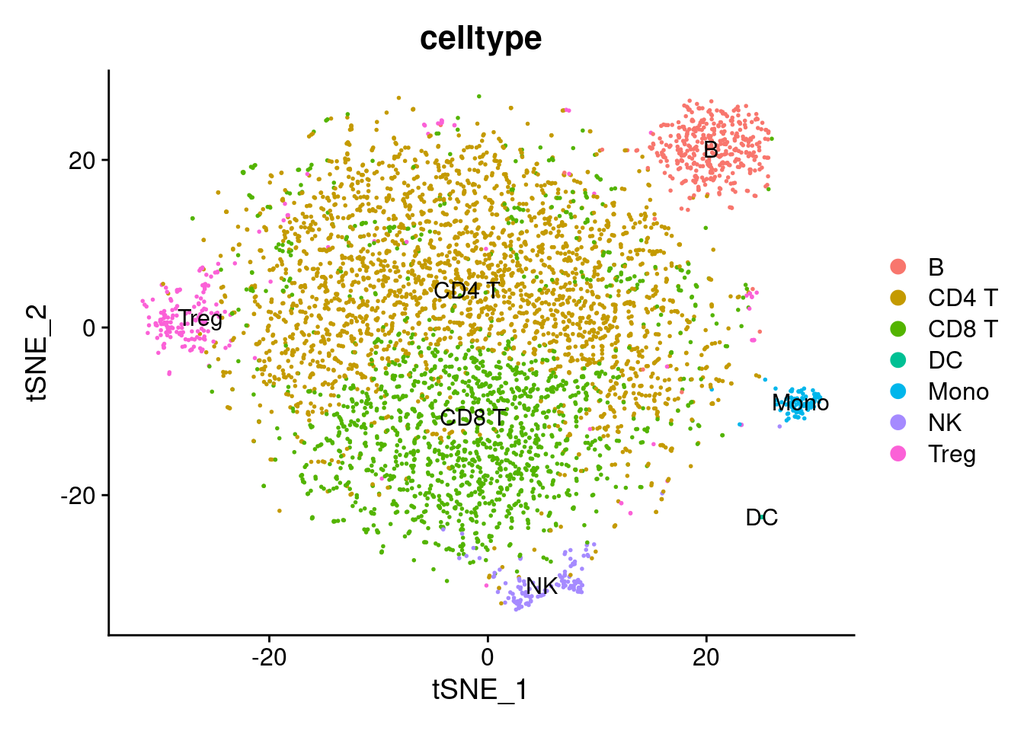

```r
seurat_obj <-
    readRDS("/gpfs0/home/gdworkshop/lab/session_data/06/seuratObj.rds")

DimPlot(seurat_obj, group.by = "celltype", label = TRUE)
```

## Convert gene names in model to mouse

```r
lr_network <-
    lr_network %>%
    mutate(from = convert_human_to_mouse_symbols(from),
           to = convert_human_to_mouse_symbols(to)) %>%
    drop_na()

colnames(ligand_target_matrix) <-
    ligand_target_matrix %>%
    colnames() %>%
    convert_human_to_mouse_symbols()

rownames(ligand_target_matrix) <-
    ligand_target_matrix %>%
    rownames() %>%
    convert_human_to_mouse_symbols()

ligand_target_matrix <-
    ligand_target_matrix %>%
    .[!is.na(rownames(ligand_target_matrix)),
        !is.na(colnames(ligand_target_matrix))]

weighted_networks_lr <-
    weighted_networks_lr %>%
    mutate(from = convert_human_to_mouse_symbols(from),
           to = convert_human_to_mouse_symbols(to)) %>%
    drop_na()
```

## Define sender and reciever cells

Also get lists of genes expressed in receiver cells

```r
## receiver
receiver <- "CD8 T"
expressed_genes_receiver <-
    get_expressed_genes(receiver,
                        seurat_obj,
                        pct = 0.10)

background_expressed_genes <-
    expressed_genes_receiver %>%
    .[. %in% rownames(ligand_target_matrix)]

## sender
sender_celltypes <- c("CD4 T",
                      "Treg",
                      "Mono",
                      "NK",
                      "B",
                      "DC")
```

## Make sure to keep only genes present in our model

```r
list_expressed_genes_sender <-
    sender_celltypes %>%
    # lapply to get the expressed genes of every sender cell type separately here
    lapply(get_expressed_genes, seurat_obj, 0.10)

expressed_genes_sender <-
    list_expressed_genes_sender %>%
    unlist() %>%
    unique()
```

## Use FindMarkers to define out genes of interest

Can use other methods to define the group of genes you want to look at Get just the reciever cells and do DE based on conditions (“aggregate” in this case) Then make sure these genes are in our model

```r
seurat_obj_receiver <-
    subset(seurat_obj, idents = receiver) %>%
    SetIdent(value = "aggregate")

DE_table_receiver <-
    FindMarkers(object = seurat_obj_receiver,
                ident.1 = "LCMV",
                ident.2 = "SS",
                min.pct = 0.10) %>%
    rownames_to_column("gene")

geneset_oi <-
    DE_table_receiver %>%
    filter(p_val_adj <= 0.05 &
            abs(avg_log2FC) >= 0.25) %>%
    pull(gene) %>%
    .[. %in% rownames(ligand_target_matrix)]

head(geneset_oi)
```

```
## [1] "Irf7"   "Stat1"  "Ifit3"  "Ifit1"  "Bst2"   "Rnf213"
```

## Define potential ligands

Take the list of ligands from our model and keep the ones that are expressed in our data and do the same for the receptors Then use these lists to keep ligands where both the receptor and the ligand are expressed

```r
ligands <-
    lr_network %>%
    pull(from) %>%
    unique()

receptors <-
    lr_network %>%
    pull(to) %>%
    unique()

expressed_ligands <- intersect(ligands, expressed_genes_sender)
expressed_receptors <- intersect(receptors, expressed_genes_receiver)

potential_ligands <-
    lr_network %>%
    filter(from %in% expressed_ligands &
            to %in% expressed_receptors) %>%
    pull(from) %>%
    unique()
```

## Predict which ligands best explain the expressed genes in the reciever cells

We provide:

- geneset_oi - List of downstream targets of potentially activated receptors
- background_expressed_genes - List of genes expressed in the reciever cells
- ligand_target_matrix - Matrix of ligand-receptor interactions
- potential_ligands - List of ligands that are expressed in the sender cells

How you generate these lists is flexible

```r
nichenet_stepwise_output <-
    predict_ligand_activities(geneset = geneset_oi,
                              background_expressed_genes = background_expressed_genes,
                              ligand_target_matrix = ligand_target_matrix,
                              potential_ligands = potential_ligands) %>%
    arrange(-pearson) %>%
    mutate(rank = rank(desc(pearson)))

nichenet_stepwise_output
```

```
## # A tibble: 44 × 6
##    test_ligand auroc   aupr aupr_corrected  pearson  rank
##    <chr>       <dbl>  <dbl>          <dbl>    <dbl> <dbl>
##  1 Ebi3        0.690 0.211         0.128    0.229       1
##  2 Il15        0.589 0.112         0.0286   0.0800      2
##  3 Crlf2       0.555 0.122         0.0380   0.0757      3
##  4 Tgfb1       0.455 0.0965        0.0129   0.0553      4
##  5 App         0.444 0.0880        0.00436  0.0411      5
##  6 Ptprc       0.506 0.0954        0.0117   0.0264      6
##  7 H2-M3       0.482 0.101         0.0172   0.0115      7
##  8 Icam1       0.509 0.0872        0.00355  0.0101      8
##  9 Cxcl10      0.499 0.0867        0.00299  0.00333     9
## 10 Ccl5        0.513 0.0852        0.00156 -0.00438    10
## # … with 34 more rows
```

```r
qs::qsave(nichenet_stepwise_output,
          file = "/gpfs0/home/gdworkshop/lab/session_data/06/nichenet_stepwise_output.qs")
```

## Easy mode

This will work if you are comparing between two conditions such as treated/untreated

```r
ligand_target_matrix <-
    readRDS("/home/gdworkshop/lab/session_data/06/ligand_target_matrix.rds")

lr_network <-
    readRDS("/home/gdworkshop/lab/session_data/06/lr_network.rds")

weighted_networks <-
    readRDS("/home/gdworkshop/lab/session_data/06/weighted_networks.rds")

Idents(seurat_obj) <- "celltype"
nichenet_easy_output <-
    nichenet_seuratobj_aggregate(seurat_obj = seurat_obj,
                                 receiver = "CD8 T",
                                 condition_colname = "aggregate",
                                 condition_oi = "LCMV",
                                 condition_reference = "SS",
                                 sender = c("CD4 T",
                                            "Treg",
                                            "Mono",
                                            "NK",
                                            "B",
                                            "DC"),
                                 ligand_target_matrix = ligand_target_matrix,
                                 lr_network = lr_network,
                                 weighted_networks = weighted_networks,
                                 organism = "mouse")
```

```
## [1] "Read in and process NicheNet's networks"
## [1] "Define expressed ligands and receptors in receiver and sender cells"
## [1] "Perform DE analysis in receiver cell"
## [1] "Perform NicheNet ligand activity analysis"
## [1] "Infer active target genes of the prioritized ligands"
## [1] "Infer receptors of the prioritized ligands"
## [1] "Perform DE analysis in sender cells"
```

```r
qs::qsave(nichenet_easy_output,
          file = "/gpfs0/home/gdworkshop/lab/session_data/06/nichenet_easy_output.qs")
```

# Activity 1 (1:30 - 2ish)

We need:

- geneset_oi - List of downstream targets of potentially activated receptors
- background_expressed_genes - List of genes expressed in the reciever cells
- ligand_target_matrix - Matrix of ligand-receptor interactions
- potential_ligands - List of ligands that are expressed in the sender cells

## Get data to use

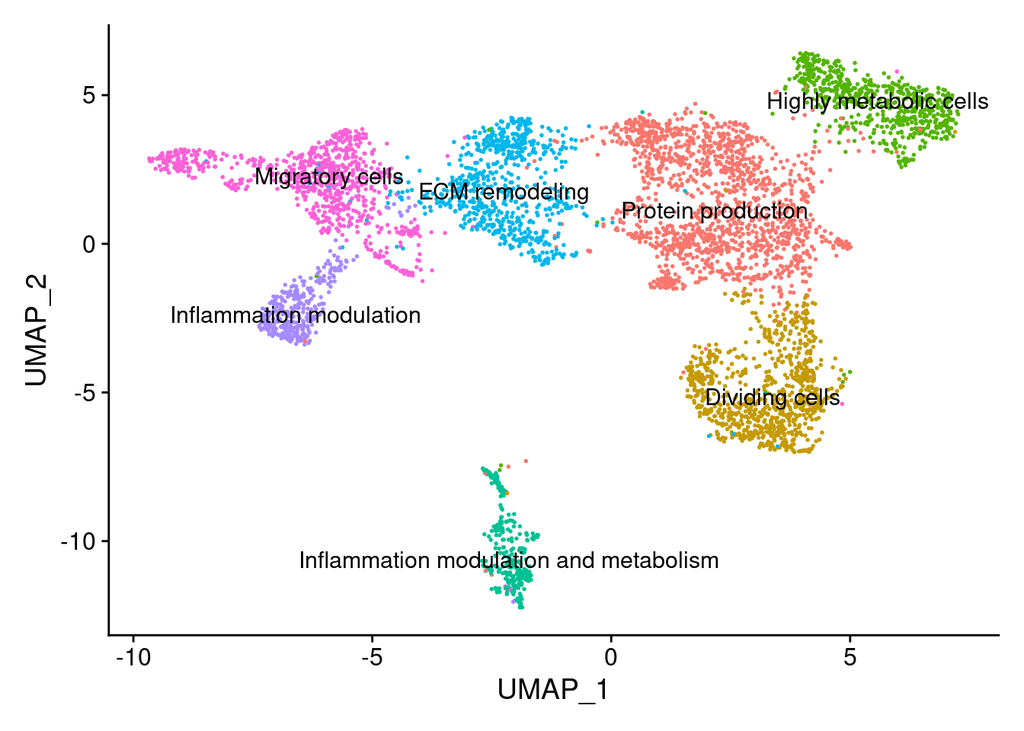

```r
tumor_h <- qs::qread("/home/gdworkshop/lab/session_data/os_shark_400.qs")
Idents(tumor_h) <- "mol_funct"
DimPlot(tumor_h, label = TRUE) +
    NoLegend()
```

## Get reference model

```r
ligand_target_matrix <-
    readRDS("/home/gdworkshop/lab/session_data/06/ligand_target_matrix.rds")

lr_network <-
    readRDS("/home/gdworkshop/lab/session_data/06/lr_network.rds")

weighted_networks <-
    readRDS("/home/gdworkshop/lab/session_data/06/weighted_networks.rds")
```

## Define sender/reciever cells

```r
sender_cells <-
    c("Inflammation modulation and metabolism",
      "Inflammation modulation",
      "Highly metabolic cells")
sender_clusters <- c(6, 5, 4)

receiver_cells <- "Migratory cells"
receiver_cluster <- 2
```

## Get genes of interest

We’re interested in the genes that make this cluster unique, based on GSEA

```r
pathways <-
    qs::qread("../../os_shark_400_pathways.qs") %>%
    filter(cluster == receiver_cluster &
           NES > 0 &
           p.adjust < 1e-10)

# Make a vector all genes from upregulated pathways
genes_of_interest <-
    pathways$core_enrichment %>%
    str_split("/") %>%
    unlist() %>%
    unique() %>%
    .[. %in% rownames(ligand_target_matrix)]
```

## Define background genes in receiver cells

```r
background_receiver_genes <-
    get_expressed_genes(receiver_cells,
                        tumor_h,
                        pct = 0.10) %>%
    .[. %in% rownames(ligand_target_matrix)]
```

## Define potential ligands

```r
ligands <-
    lr_network %>%
    pull(from) %>%
    unique()

receptors <-
    lr_network %>%
    pull(to) %>%
    unique()

expressed_genes_senders <-
    sender_cells %>%
    # lapply to get the expressed genes of every sender cell type separately here
    lapply(get_expressed_genes, tumor_h, 0.10) %>%
    unlist() %>%
    unique()

expressed_genes_receiver <-
    get_expressed_genes(receiver_cells,
                        tumor_h,
                        pct = 0.10) %>%
    unlist() %>%
    unique()

expressed_ligands <- intersect(ligands, expressed_genes_senders)
expressed_receptors <- intersect(receptors, expressed_genes_receiver)

potential_ligands <-
    lr_network %>%
    filter(from %in% expressed_ligands &
            to %in% expressed_receptors) %>%
    pull(from) %>%
    unique()
```

## Run nichenetr

```r
activity_1_output <-
    predict_ligand_activities(geneset = genes_of_interest,
                              background_expressed_genes = background_receiver_genes,
                              ligand_target_matrix = ligand_target_matrix,
                              potential_ligands = potential_ligands) %>%
    arrange(-pearson) %>%
    mutate(rank = rank(desc(pearson)))

activity_1_output
```

```
## # A tibble: 216 × 6
##    test_ligand auroc   aupr aupr_corrected pearson  rank
##    <chr>       <dbl>  <dbl>          <dbl>   <dbl> <dbl>
##  1 TGFB1       0.733 0.127          0.108    0.222     1
##  2 IL1B        0.686 0.0808         0.0620   0.171     2
##  3 SPP1        0.663 0.0817         0.0628   0.157     3
##  4 POMC        0.675 0.0540         0.0352   0.130     4
##  5 TGFB3       0.663 0.0614         0.0426   0.127     5
##  6 VEGFA       0.681 0.0568         0.0379   0.126     6
##  7 FGF1        0.673 0.0621         0.0432   0.121     7
##  8 CTGF        0.684 0.0633         0.0445   0.121     8
##  9 AGT         0.668 0.0546         0.0357   0.120     9
## 10 APOE        0.676 0.0467         0.0279   0.118    10
## # … with 206 more rows
```

```r
qs::qsave(activity_1_output, file = "/home/gdworkshop/lab/session_data/06/activity_1_output.qs")
```

Run nichenetr on os-shark? # Section 2: Visualizing nichenetr results

# Activity (2:30 - 3ish)

Make plots from nichenetr outputs?

# Section 3: Interpreting nichenetr results

Activity (3:30 - 4ish)

## Easy mode output:

Important outputs - $ligand_activities: data frame with output ligand activity analysis - $top_ligands: top_n ligands based on ligand activity - $top_targets: active, affected target genes of these ligands - $top_receptors: receptors of these ligands - $ligand_activity_target_heatmap: heatmap showing both ligand activity scores and target genes of these top ligands - $ligand_expression_dotplot: expression dotplot of the top ligands - $ligand_differential_expression_heatmap = differential expression heatmap of the top ligands - $ligand_target_heatmap: heatmap of ligand-target regulatory potential - $ligand_receptor_heatmap: heatmap showing ligand-receptor interactions

Saved input info - $ligand_target_matrix: matrix indicating regulatory potential scores between active ligands and their predicted targets - $ligand_target_df: data frame showing regulatory potential scores of predicted active ligand-target network - $ligand_receptor_matrix: matrix of ligand-receptor interactions - $ligand_receptor_df: data frame of ligand-receptor interactions - $ligand_receptor_matrix_bonafide: ligand-receptor matrix, after filtering out interactions predicted by PPI - $ligand_receptor_heatmap_bonafide: heatmap of ligand-receptor interactions after filtering out interactions predicted by PPI - $ligand_receptor_df_bonafide: data frame of ligand-receptor interactions, after filtering out interactions predicted by PPI - $geneset_oi: a vector containing the set of genes used as input for the ligand activity analysis - $background_expressed_genes: the background of genes to which the geneset will be compared in the ligand activity analysis.

# Session challenge

Run nichenetr on your own data or data from some random paper Run cell-cell interaction analysis with another package Compare the two

# Resources

https://www.ncbi.nlm.nih.gov/pmc/articles/PMC9184522/ https://www.nature.com/articles/s41592-019-0667-5

# Extra stuff to run Differential NicheNetr

```r
lr_network <-
    readRDS("/home/gdworkshop/lab/session_data/06/lr_network.rds") %>%
    mutate(bonafide = !database %in% c("ppi_prediction",
                                        "ppi_prediction_go")) %>%
    dplyr::rename(ligand = from, receptor = to) %>%
    distinct(ligand, receptor, bonafide)
```

## Get data to work with

From “https://zenodo.org/record/5840787/files/seurat_obj_subset_integrated_zonation.rds”

```r
seurat_obj <-
    readRDS("/gpfs0/home/gdworkshop/lab/session_data/06/seurat_obj_subset_integrated_zonation.rds")
```

## Convert the species from human to mouse

```r
head(lr_network)
lr_network <-
    lr_network %>%
    mutate(ligand = convert_human_to_mouse_symbols(ligand),
           receptor = convert_human_to_mouse_symbols(receptor)) %>%
    drop_na()
head(lr_network)

colnames(ligand_target_matrix) <-
    ligand_target_matrix %>%
    colnames() %>%
    convert_human_to_mouse_symbols()

rownames(ligand_target_matrix) <-
    ligand_target_matrix %>%
    rownames() %>%
    convert_human_to_mouse_symbols()

ligand_target_matrix <-
    ligand_target_matrix %>%
    .[!is.na(rownames(ligand_target_matrix)),
        !is.na(colnames(ligand_target_matrix))]
```

## Define which cells we’re comparing

```r
niche_list <- list(
    "KC_niche" = list("sender" = c("LSECs_portal",
                                   "Hepatocytes_portal",
                                   "Stellate cells_portal"),
                      "receiver" = c("KCs")),
    "MoMac2_niche" = list("sender" = c("Cholangiocytes",
                                       "Fibroblast 2"),
                          "receiver" = c("MoMac2")),
    "MoMac1_niche" = list("sender" = c("Capsule fibroblasts",
                                       "Mesothelial cells"),
                          "receiver" = c("MoMac1"))
  )
```

## Do DE to define genes of interest

### There were originally multiple SCT-transformed assays, so we need to integrate them

```r
assay_name <- "SCT"

seurat_obj <-
    PrepSCTFindMarkers(seurat_obj,
                       assay = assay_name,
                       verbose = FALSE)
```

### Do DE between niches, then process the results

Run DE analysis, then get rid of infinite values and calculate further statistics for DE genes

```r
expression_pct <- 0.10
de_sender_processed <-
    calculate_niche_de(seurat_obj = seurat_obj %>%
                            subset(features = lr_network$ligand %>%
                                intersect(rownames(seurat_obj))),
                       niches = niche_list,
                       type = "sender",
                       assay_oi = assay_name) %>%
    # Fix any infinite values by making them the max/min finite value
    mutate(avg_log2FC = ifelse(avg_log2FC == Inf,
                               max(avg_log2FC[is.finite(avg_log2FC)]),
                               ifelse(avg_log2FC == -Inf,
                                      min(avg_log2FC[is.finite(avg_log2FC)]),
                                      avg_log2FC))) %>%
    process_niche_de(niches = niche_list,
                     expression_pct = expression_pct,
                     type = "sender")

de_receiver_processed <-
    calculate_niche_de(seurat_obj = seurat_obj %>%
                            subset(features = lr_network$receptor %>%
                                   unique()),
                       niches = niche_list,
                       type = "receiver",
                       assay_oi = assay_name) %>%
    # Fix any infinite values by making them the max/min finite value
    mutate(avg_log2FC = ifelse(avg_log2FC == Inf,
                               max(avg_log2FC[is.finite(avg_log2FC)]),
                               ifelse(avg_log2FC == -Inf,
                                      min(avg_log2FC[is.finite(avg_log2FC)]),
                                      avg_log2FC))) %>%
    process_niche_de(niches = niche_list,
                     expression_pct = expression_pct,
                     type = "receiver")
```

```r
de_sender_receiver <-
    combine_sender_receiver_de(de_sender_processed,
                               de_receiver_processed,
                               lr_network,
                               specificity_score = "min_lfc")
```

```r
lfc_cutoff <- 0.15

de_receiver_processed_targets <-
    calculate_niche_de_targets(seurat_obj = seurat_obj,
                               niches = niche_list,
                               lfc_cutoff = lfc_cutoff,
                               expression_pct = expression_pct,
                               assay_oi = assay_name) %>%
    process_receiver_target_de(niches = niche_list,
                               expression_pct = expression_pct,
                               specificity_score = "min_lfc")

background <-
    de_receiver_processed_targets  %>%
    pull(target) %>%
    unique()

geneset_KC <-
    de_receiver_processed_targets %>%
    filter(receiver == niche_list$KC_niche$receiver &
            target_score >= lfc_cutoff &
            target_significant == 1 &
            target_present == 1) %>%
    pull(target) %>%
    unique()

geneset_MoMac2 <-
    de_receiver_processed_targets %>%
    filter(receiver == niche_list$MoMac2_niche$receiver &
            target_score >= lfc_cutoff &
            target_significant == 1 &
            target_present == 1) %>%
    pull(target) %>%
    unique()

geneset_MoMac1 <-
    de_receiver_processed_targets %>%
    filter(receiver == niche_list$MoMac1_niche$receiver &
            target_score >= lfc_cutoff &
            target_significant == 1 &
            target_present == 1) %>%
    pull(target) %>%
    unique()
```

```r
top_n_target <- 250

niche_geneset_list <- list(
    "KC_niche" = list("receiver" = "KCs",
                      "geneset" = geneset_KC,
                      "background" = background),
    "MoMac1_niche" = list("receiver" = "MoMac1",
                          "geneset" = geneset_MoMac1,
                          "background" = background),
    "MoMac2_niche" = list("receiver" = "MoMac2",
                          "geneset" = geneset_MoMac2,
                          "background" = background))

ligand_activities_targets <-
    get_ligand_activities_targets(niche_geneset_list = niche_geneset_list,
                                  ligand_target_matrix = ligand_target_matrix,
                                  top_n_target = top_n_target)
```

## Get table of normalized expression values for genes of interest

```r
features_oi <-
    union(lr_network$ligand,
          lr_network$receptor) %>%
    union(ligand_activities_targets$target) %>%
    setdiff(NA)

exprs_tbl <-
    suppressWarnings(Seurat::DotPlot(seurat_obj %>%
                                     subset(idents = niche_list %>%
                                            unlist() %>%
                                            unique()),
                                     features = features_oi,
                                     assay = assay_name))$data %>%
    as_tibble() %>%
    rename(celltype = id,
           gene = features.plot,
           expression = avg.exp,
           expression_scaled = avg.exp.scaled,
           fraction = pct.exp) %>%
    mutate(fraction = fraction / 100) %>%
    as_tibble() %>%
    select(celltype,
           gene,
           expression,
           expression_scaled,
           fraction) %>%
    distinct() %>%
    arrange(gene) %>%
    mutate(gene = as.character(gene))
```

```r
exprs_tbl_ligand <-
    exprs_tbl %>%
    filter(gene %in% lr_network$ligand) %>%
    rename(sender = celltype,
           ligand = gene,
           ligand_expression = expression,
           ligand_expression_scaled = expression_scaled,
           ligand_fraction = fraction) %>%
    mutate(scaled_ligand_expression_scaled =
                scale_quantile_adapted(ligand_expression_scaled),
           ligand_fraction_adapted = ligand_fraction) %>%
    mutate_cond(ligand_fraction >= expression_pct,
                ligand_fraction_adapted = expression_pct)  %>%
    mutate(scaled_ligand_fraction_adapted =
                scale_quantile_adapted(ligand_fraction_adapted))

exprs_tbl_receptor <-
    exprs_tbl %>%
    filter(gene %in% lr_network$receptor) %>%
    rename(receiver = celltype,
           receptor = gene,
           receptor_expression = expression,
           receptor_expression_scaled = expression_scaled,
           receptor_fraction = fraction) %>%
    mutate(scaled_receptor_expression_scaled =
                scale_quantile_adapted(receptor_expression_scaled),
           receptor_fraction_adapted = receptor_fraction) %>%
    mutate_cond(receptor_fraction >= expression_pct,
                receptor_fraction_adapted = expression_pct) %>%
    mutate(scaled_receptor_fraction_adapted =
                scale_quantile_adapted(receptor_fraction_adapted))

exprs_tbl_target <-
    exprs_tbl %>%
    filter(gene %in% ligand_activities_targets$target) %>%
    rename(receiver = celltype,
           target = gene,
           target_expression = expression,
           target_expression_scaled = expression_scaled,
           target_fraction = fraction)
```

```r
exprs_sender_receiver <-
    lr_network %>%
    inner_join(exprs_tbl_ligand, by = c("ligand"), multiple = "all") %>%
    inner_join(exprs_tbl_receptor, by = c("receptor"), multiple = "all") %>%
    inner_join(de_sender_receiver %>%
                    distinct(niche, sender, receiver), multiple = "all")
```

```r
ligand_scaled_receptor_expression_fraction_df <-
    exprs_sender_receiver %>%
    group_by(ligand, receiver) %>%
    mutate(rank_receptor_expression = dense_rank(receptor_expression),
           rank_receptor_fraction  = dense_rank(receptor_fraction)) %>%
    mutate(ligand_scaled_receptor_expression_fraction =
                0.5 * ((rank_receptor_fraction / max(rank_receptor_fraction)) +
                     ((rank_receptor_expression / max(rank_receptor_expression)))))  %>%
    distinct(ligand,
             receptor,
             receiver,
             ligand_scaled_receptor_expression_fraction,
             bonafide) %>%
    distinct() %>%
    ungroup()
```

```r
prioritizing_weights <-
    c("scaled_ligand_score" = 5,
      "scaled_ligand_expression_scaled" = 1,
      "ligand_fraction" = 1,
      "scaled_ligand_score_spatial" = 2,
      "scaled_receptor_score" = 0.5,
      "scaled_receptor_expression_scaled" = 0.5,
      "receptor_fraction" = 1,
      "ligand_scaled_receptor_expression_fraction" = 1,
      "scaled_receptor_score_spatial" = 0,
      "scaled_activity" = 0,
      "scaled_activity_normalized" = 1,
      "bona_fide" = 1)
```

### Make fake spatial data since we don’t have it

```r
spatial_info <-
    tibble(celltype_region_oi = c("LSECs_portal",
                                  "Hepatocytes_portal",
                                  "Stellate cells_portal"),
           celltype_other_region = c("LSECs_central",
                                     "Hepatocytes_central",
                                     "Stellate cells_central")) %>%
  mutate(niche =  "KC_niche",
         celltype_type = "sender")

sender_spatial_de_processed <-
    get_non_spatial_de(niches = niche_list,
                       spatial_info = spatial_info,
                       type = "sender",
                       lr_network = lr_network) %>%
    mutate(scaled_ligand_score_spatial =
            scale_quantile_adapted(ligand_score_spatial))

receiver_spatial_de_processed <-
    get_non_spatial_de(niches = niche_list,
                       spatial_info = spatial_info,
                       type = "receiver",
                       lr_network = lr_network) %>%
    mutate(scaled_receptor_score_spatial =
            scale_quantile_adapted(receptor_score_spatial))
```

```r
output <-
    list(DE_sender_receiver = de_sender_receiver,
         ligand_scaled_receptor_expression_fraction_df =
                ligand_scaled_receptor_expression_fraction_df,
         sender_spatial_DE_processed = sender_spatial_de_processed,
         receiver_spatial_DE_processed = receiver_spatial_de_processed,
         ligand_activities_targets = ligand_activities_targets,
         DE_receiver_processed_targets = de_receiver_processed_targets,
         exprs_tbl_ligand = exprs_tbl_ligand,
         exprs_tbl_receptor = exprs_tbl_receptor,
         exprs_tbl_target = exprs_tbl_target)

prioritization_tables <- get_prioritization_tables(output, prioritizing_weights)
qs::qsave(prioritization_tables, "Sessions/06/prioritization_tables.rds")
```